# Primo Homework

## 4.d: Calcola la media dell’aspettativa di vita per l’Australia. Come si potrebbe confrontarla con quella degli altri Stati?

```r
# Calcolo la media della variabile "value" per l'Australia
media_aus <- mean(life_clean$value[life_clean$country_name == "Australia"])

# Visualizzo il risultato
print(media_aus)
```

```
## [1] 76.71743
```

```r
# Carico la libreria dplyr
library(dplyr)
# Calcolo la media dell'aspettativa di vita per tutti i Paesi
medie_paesi <- life_clean %>%
  group_by(country_name) %>%
  summarise(media = mean(value, na.rm = TRUE))

# Ordino i paesi per media decrescente
medie_paesi_ordinate <- medie_paesi %>% arrange(desc(media))

# Visualizzo la classifica
print(medie_paesi_ordinate)
```

```
## # A tibble: 17 × 2
##    country_name                media
##    <fct>                       <dbl>
##  1 Finland                      81.4
##  2 Australia                    76.7
##  3 Austria                      75.4
##  4 Antigua and Barbuda          73.1
##  5 Aruba                        71.9
##  6 Albania                      71.4
##  7 Argentina                    71.0
##  8 United Arab Emirates         69.6
##  9 Armenia                      68.2
## 10 Azerbaijan                   63.4
## 11 Arab World                   61.0
## 12 Zimbabwe                     58.8
## 13 Fiji                         58.6
## 14 Africa Eastern and Southern  51.7
## 15 Africa Western and Central   48.2
## 16 Afghanistan                  47.7
## 17 Angola                       46.4
```

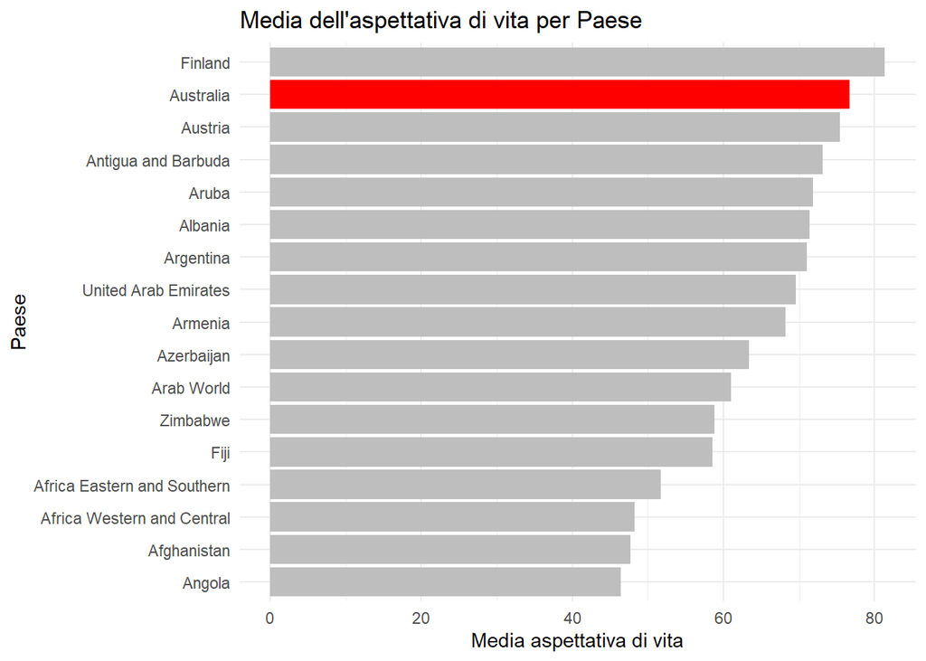

```r
# L'Australia risulta tra i primi paesi con la media più alta dell'aspettativa di vita.

# Carico la libreria ggplot2, per visualizzare il grafico
library(ggplot2)

# Creo il grafico:

ggplot(medie_paesi, aes(x = reorder(country_name, media), y = media)) +
  geom_bar(stat = "identity", fill = "grey") +
  coord_flip() +   # Ruota il grafico per una lettura più comoda
  theme_minimal() +
  labs(
    title = "Media dell'aspettativa di vita per Paese",
    x = "Paese",
    y = "Media aspettativa di vita"
  ) +
  geom_bar(data = subset(medie_paesi, country_name == "Australia"),
           aes(x = country_name, y = media),
           stat = "identity", fill = "red")
```

### ESERCIZIO 5: Costruisci una matrice 2x3 composta da multipli di 2

```r
# Creo i multipli di 2 fino a 12
valori <- seq (2, 12, by = 2)

# Creo la matrice 2 x 3
matrice <- matrix(valori, nrow = 2)
print(matrice)
```

```
##      [,1] [,2] [,3]
## [1,]    2    6   10
## [2,]    4    8   12
```

## 5.a: Che cosa succede usando il comando is.matrix? E il comando is.array?

```r
# Verifico se la matrice è una matrice.  Output = TRUE
is.matrix(matrice)
```

```
## [1] TRUE
```

```r
# Verifico se la matrice è un array.     Output = TRUE
is.array(matrice)
```

```
## [1] TRUE
```

```r
### INFO ###:
# is.matrix: Controlla se l'oggetto è una matrice. E' TRUE perchè e una matrice
# is.array: Controlla se l'oggetto è un array. E' TRUE perchè in R
#           le matrici sono considerate un caso particolare di array
```

## 5.b: Estrai la 3 colonna da questa matrice, chiamando l’oggetto estratto b. Che tipo di oggetto è?

```r
# Estraggo la terza colonna della matrice
b <- matrice [, 3]

# Mostro l'oggetto estratto
print(b)
```

```
## [1] 10 12
```

```r
# Verifico il tipo di oggetto. Output: Vettore (numeric)
class(b)
```

```
## [1] "numeric"
```

## 5.c: Converti b in matrice.

```r
# Converto 'b' in matrice
b_matrice <- as.matrix(b)

# Mostra l'oggetto convertito
print(b_matrice)
```

```
##      [,1]
## [1,]   10
## [2,]   12
```

```r
# Verifico il tipo di oggetto
class(b_matrice)
```

```
## [1] "matrix" "array"
```

### ESERCIZIO 6: Il file ‘nazioni.csv’ contiene info su 105 Nazioni, e per ognuna di esse riporta:

- areaGeo: La regione geografica
- reddito: Il reddito pro capite in dollari
- infmort: Il tasso di mortalità infantile (morti ogni 100 nascite)
- oil: Se il paese esporta petrolio (1 = no; 2 = sì)

## 6.a: Caricare i dati nello spazio di lavoro in un data frame chiamato “nazioni”, stampare il numero di righe dell’oggetto importato ed il nome delle variabili.

```r
# Carico il dataset
nazioni <- read.csv("nazioni.csv", stringsAsFactors = FALSE)

# Visualizzo il data frame
View(nazioni)

# Stampo il numero di righe
numero_righe <- nrow(nazioni)
print(numero_righe)
```

```
## [1] 105
```

```r
# Stampo i nomi delle variabili
nomi_variabili <- names(nazioni)
print(nomi_variabili)
```

```
## [1] "nome"    "areaGeo" "reddito" "infmort" "oil"
```

```r
### INFO ###:
# read.csv: Importa i dati senza trasformare subito i testi in fattori
# nrow: Restituisce il numero di RIGHE del dataset
# names: Mostra i NOMI DELLE COLONNE (le variabili del dataset)
```

## 6.b: Stampare il vettore con il numero di valori mancanti presenti in ogni variabile.

```r
# Calcolo il numero di valori mancanti per ogni variabile
valore_mancante <- colSums(is.na(nazioni))

# Stampa risultato
print(valore_mancante)
```

```
##    nome areaGeo reddito infmort     oil
##       0       0       0       4       3
```

```r
### INFO ###:
# is.na(): Restituisce un dataframe di valori logici (TRUE o FALSE), dove TRUE
#          indica che il valore è mancante.
# colSums(is.na()): Somma i valori TRUE per ogni colonna,
#                   dandoci il numero di valori mancanti per ciascuna variabile.
```

## 6.c: Ottenere il nome dei Paesi in cui sono presenti valori mancanti.

```r
# Seleziona le righe con almeno un valore mancante
paesi_con_na <- nazioni[!complete.cases(nazioni), ]

# Estrai i nomi dei Paesi con valori mancanti
paesi_con_na_nome <- paesi_con_na$nome

# Stampa i nomi dei Paesi con valori mancanti
print(paesi_con_na_nome)
```

```
## [1] "Iran"        "Austria"     "El Salvador" "Haiti"       "Laos"
## [6] "Nepal"
```

```r
### INFO ###:
# !complete.cases(): Restituisce un vettore logico che indica:
#                    FaLSE: Righe senza NA,      TRUE: Righe con almeno un NA
# paesi_con_na$nome: Estrae solo i nomi dei Paesi da queste righe filtrate.
# nazioni[!()]: Crea un nuovo dataframe con le righe che hanno NA
```

## 6.d: Eliminare i valori mancanti dal data set.

```r
# Elimino tutte le righe con almeno un valore mancante
nazioni <- na.omit(nazioni)

# Controllo che non ci siano più valori mancanti
print(colSums(is.na(nazioni)))
```

```
##    nome areaGeo reddito infmort     oil
##       0       0       0       0       0
```

```r
# Visualizzo di nuovo il dataset pulito
View(nazioni)

### INFO ###:
# na.omit(): Crea una versione pulita del dataset, togliendo tutte le righe che avevano NA.
# colSums(): Mi permette di verificare che tutti i valori
#            sono completi (tutte le colonne devono risultare con 0 NA)
```